# Statistical Programming in R: Lecture 6

Data Reshaping

Josemari Feliciano

## Administrative: First midterm

1. First midterm will be on October 14th (Tuesday).
2. Open ‘book’ exam: open notes. **But you need to work on it by yourself only.**
3. It will be published and go live on Canvas starting at 5:30 pm.
4. Exam should take you 2 hours to complete. I will give you a ‘grace period’ in case of technology or personal issues; exam deliverables are due by 8:30.00 pm.
5. I will accept late submission up to 11:59pm of October 14th but your final exam score would be penalized by 15% off.
6. You may take it anywhere. But I will be present in our classroom in case you want to take it in-person to ask clarifying questions.
7. Study: Lecture materials, in-class exercises, and homework problems.
8. Exam will cover materials covered up to the 10/7 lecture although the 10/7 material will not be a primary exam focus.

## Midterm Format

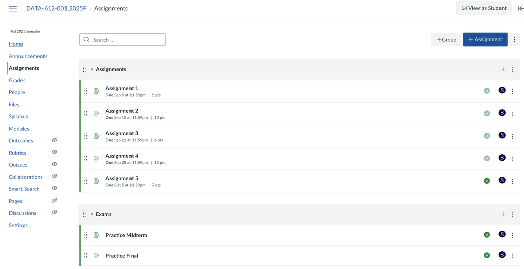

## Final Project

Let us quickly switch to Canvas to discuss the **Dataset(s) Approval For Final Project** assignment due on October 31st (4-5 weeks).

## Homework solutions

Solution guides to Homework 1-3 were posted in Canvas under **Home** > **Homework Solutions** (or **Modules** > **Homework Solutions**)

**Reminder:** Homework 5 due this Friday at 11:59pm.

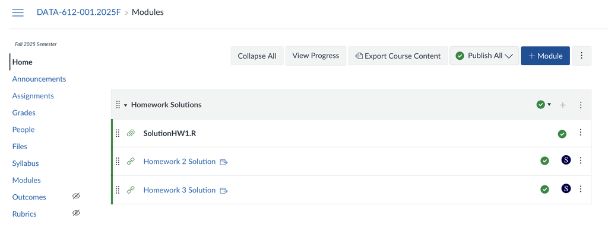

# Today’s agenda

1. Revisiting Pipes (|>)
2. Data Reshaping using tidyr package (Chapter 5: Data tidying)

The tidyr package is a **core tidyverse package**, so it is loaded as one of the packages loaded by `library(tidyverse)`.

Before proceeding, I will run the following scripts:

```r
library(tidyverse)
library(palmerpenguins)
data("penguins")
```

**Note:** Detailed discussions we are about to have about pipes will not be covered in any of your exams. They are very technical, and your book doesn’t even cover them in this great detail. I just want to provide detailed context on why or how they work.

## Two Primary Pipes in R

- Native pipe: `|>`

The pipe finally landed in the R stable version 4.1.0, which was released in 2021. We call it the native pipe because it is native in R, which means it doesn’t require you to install and load an R package prior to its use.

- Magrittr (basic) pipe: `%>%`

For the past decade, R users primarily used the magrittr basic pipe until the introduction of the native pipe in 2021. The magrittr pipe is enabled after you load the tidyverse package since the tidyverse loads the magrittr package as one of the packages it loads.

Within the context of working with tidyverse packages (e.g., dplyr verbs), `%>%` and `|>` are *essentially* equivalent. A number of tutorials you may see online may still use this pipe.

## What the pipe actually does

Both pipes pass the previous data you have or created from the previous step into the first argument of the next function. Note: how can you tell what is the first argument of functions/tools we use? R documentation.

```r
penguins |>
  filter(sex == "male") |>
  select(species, body_mass_g)
```

What is happening above?

Step 1: The penguins data is passed to dplyr’s filter function. More specifically, it gets passed to the first argument of the filter() function, which is .data (let us quickly check this by running ?filter in an R console).

Step 2: The data produced by the filter() step is then passed to the next function which is select(). Again, the data is passed to the first argument of the select function, which is .data (let us quicky check this yet again by running ?select in an R console).

## What the pipe actually does

Pipes allow you to avoid having to create intermediary data that actually don’t need:

```r
male_penguins <- filter(.data = penguins, sex == "male")

male_penguins_v2 <- select(.data = male_penguins, species, body_mass_g)
```

**Key Note 1:** While the above is technically okay, no serious R data scientists code this way.

**Key Note 2:** I still expect you to code the way you were taught in class which is considered best practice within the community.

Tidyverse tools are called **pipe-friendly**. The first default argument of tidyverse functions are generally designed to accept data first.

## Working with non-tidyverse functions/tools

Do not assume that functions or tools from other packages (including base R) are pipe-friendly.

The following code for linear regression, a statistical modelling tool, will not work:

```r
penguins |>
  filter(sex == "male") |>
  lm(body_mass_g ~ species) |>
  summary()
```

```
## Error in as.data.frame.default(data): cannot coerce class '"formula"' to a data.frame
```

**Why the above will not work?** data is not the first default argument (it is formula).

**Is there a work around?** Yes, of course. For native pipe, you may use the placeholder symbol (_) to manually indicate where you want the prior data to be fed.

## Working with non-tidyverse functions/tools

This example leverages the placeholder symbol (_). In this scenario, I am specifically telling R to feed the filtered data into the data argument (the second argument per lm documentation).

```r
penguins |>
  filter(sex == "male") |>
  lm(body_mass_g ~ species, data = _) |>
  summary()
```

```
##
## Call:
## lm(formula = body_mass_g ~ species, data = filter(penguins, sex ==
##     "male"))
##
## Residuals:
##     Min      1Q  Median      3Q     Max
## -734.84 -234.84    6.51  215.16  861.03
##
## Coefficients:
##                  Estimate Std. Error t value Pr(>|t|)
## (Intercept)       4043.49      39.58 102.153   <2e-16 ***
## speciesChinstrap  -104.52      70.22  -1.489    0.139
## speciesGentoo     1441.34      58.67  24.568   <2e-16 ***
## ---
## Signif. codes:  0 '***' 0.001 '**' 0.01 '*' 0.05 '.' 0.1 ' ' 1
##
## Residual standard error: 338.2 on 165 degrees of freedom
## Multiple R-squared:  0.8178, Adjusted R-squared:  0.8156
## F-statistic: 370.4 on 2 and 165 DF,  p-value: < 2.2e-16
```

## Again, you will not be tested ever on what we just discussed regarding pipes.

# Two common data formats

A dataset can be written in two different formats: wide and long.

A wide format *typically* has values (e.g., Student field) that do not repeat in the first column. Your book may refer to this as tidy data.

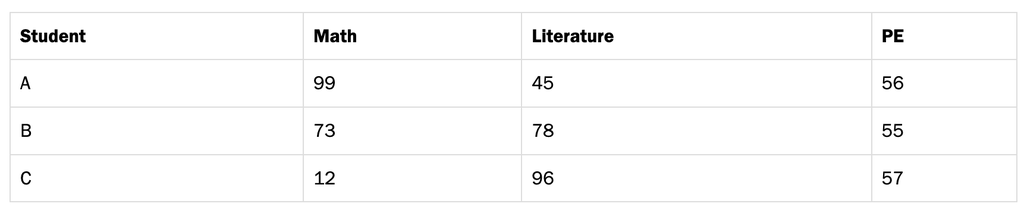

Figure 1. Example of a wide format data involving student scores.

A long format *typically* contains values that do repeat in the first column.

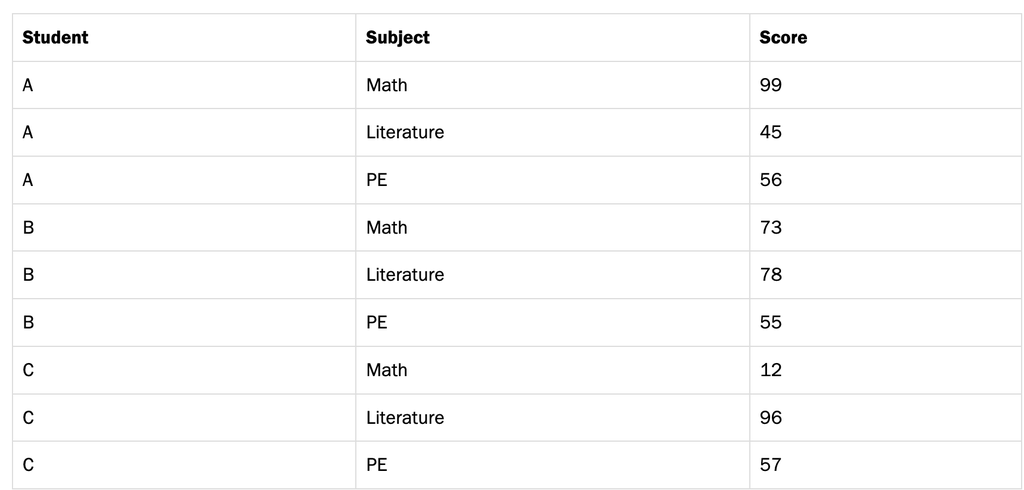

Figure 2. Example of a long format data involving student scores.

## Wide vs Long

As mentioned in the previous slide, your book generally refers to wide data as tidy data, which is *generally* the preferred format for tidyverse packages.

My personal opinion on this as a data scientist and statistician? You’ll work with both formats, so I personally don’t have a preference on wide vs long. Some analytics software (e.g., Tableau, ArcGIS) and statistical tools/packages in R and other programming languages require your data to be in long format for certain tasks, while some requires the data to be in wide format. As a data provider (i.e., processing data from databases and giving data to stakeholders), I often find myself converting long data from SQL databases into a wide formatted Excel file.

In R, the process of converting between these two data formats is often referred to as **pivoting**. It is more commonly referred to as data **reshaping** across statistical and programming languages.

## Pivoting from Long to Wide

```r
# uses read_csv to download data from my github account
student_scores_long <- read_csv("https://raw.githubusercontent.com/jmtfeliciano/teachingdata/refs/heads/main/StudentScoresLong.csv")

head(student_scores_long, 10)
```

```
## # A tibble: 9 × 3
##   student subject    score
##   <chr>   <chr>      <dbl>
## 1 A       math          99
## 2 A       literature    45
## 3 A       PE            56
## 4 B       math          73
## 5 B       literature    78
## 6 B       PE            55
## 7 C       math          12
## 8 C       literature    96
## 9 C       PE            57
```

To pivot from long to wide format, we will need to use `pivot_wider()`.

## Pivoting from Long to Wide: `pivot_wider()`

At minimum, you need to tell R which variable will be the basis for the new variables or columns (e.g., we want the class subjects to be their own columns) and which variable will be used to fill in the new variables or columns (e.g., class score from Score variable). In other words, we need to feed `names_from = subject` and `values_from = score` as arguments inside pivot_wide() as demonstrated below:

```r
score_pivotted_wider <- student_scores_long |>
  pivot_wider(
    names_from = subject, # Where the variable names will be pulled from
    values_from = score # Where the values will be pulled from
  )

score_pivotted_wider
```

```
## # A tibble: 3 × 4
##   student  math literature    PE
##   <chr>   <dbl>      <dbl> <dbl>
## 1 A          99         45    56
## 2 B          73         78    55
## 3 C          12         96    57
```

## `pivot_wider()` and Advanced Naming

Previous case:

```r
student_scores_long |>
  pivot_wider(
    names_from = subject,
    values_from = score
  )
```

```
## # A tibble: 3 × 4
##   student  math literature    PE
##   <chr>   <dbl>      <dbl> <dbl>
## 1 A          99         45    56
## 2 B          73         78    55
## 3 C          12         96    57
```

Modified naming case (you will not be tested on this):

```r
student_scores_long |>
  pivot_wider(
    names_from = subject,
    # "{subject}_final_score" tells tidyr to use the subject variable (e.g., math, literature, PE)
    # as a prefix then append it with '_final_score' at the end
    # note: variable from names_from needs to be wrapped with {} for names_glue
    names_glue = "{subject}_final_score",
    values_from = score
  )
```

```
## # A tibble: 3 × 4
##   student math_final_score literature_final_score PE_final_score
##   <chr>              <dbl>                  <dbl>          <dbl>
## 1 A                     99                     45             56
## 2 B                     73                     78             55
## 3 C                     12                     96             57
```

## Pivoting from Wide to Long

```r
student_scores_wide <- read_csv("https://raw.githubusercontent.com/jmtfeliciano/teachingdata/refs/heads/main/StudentScoresWide.csv")
head(student_scores_wide)
```

```
## # A tibble: 3 × 4
##   student statistics computer_science linear_algebra
##   <chr>        <dbl>            <dbl>          <dbl>
## 1 D               89               85             91
## 2 E               90               71            100
## 3 F               81               99             71
```

To pivot from wide to long format, we will need to use `pivot_longer()`.

## Pivoting from Wide to Long: `pivot_longer()`

```r
score_pivotted_longer <- student_scores_wide |>
  pivot_longer(
    # below: the columns you're 'collecting' into long format
    cols = statistics:linear_algebra,
    # below: what to name the column that will contain collected header names
    names_to = "subject_name",
    # below: what to name the column that will contain collected values/contents
    values_to = "final_scores"
    )

score_pivotted_longer
```

```
## # A tibble: 9 × 3
##   student subject_name     final_scores
##   <chr>   <chr>                   <dbl>
## 1 D       statistics                 89
## 2 D       computer_science           85
## 3 D       linear_algebra             91
## 4 E       statistics                 90
## 5 E       computer_science           71
## 6 E       linear_algebra            100
## 7 F       statistics                 81
## 8 F       computer_science           99
## 9 F       linear_algebra             71
```

## Download Exercise6.qmd from Canvas and open in R.